# Exploration Of Ford GoBike Data

## Preliminary Wrangling :

> Ford GoBike is a convenient way to get around the city. It’s great for short/one-way trips as well as longer recreational rides. Ford GoBike is a regional public bicycle sharing system in the San Francisco Bay Area, California. Beginning operation in August 2013, the Ford GoBike system currently has over 2,600 bicycles in 262 stations across San Francisco, East Bay and San Jose. The system is expected to expand to 7,000 bicycles around 540 stations in San Francisco, Oakland, Berkeley, Emeryville, and San Jose. The system is operated by Motivate in a partnership with the Metropolitan Transportation Commission and the Bay Area Air Quality Management District. Ford GoBike is the first regional and large-scale bicycle sharing system deployed in California and on the West Coast of the United States. As of January 2018, the system had seen nearly 500,000 rides since the launch in 2017 and had about 10,000 annual subscribers. The bikes are available for use 24 hours/day, 7 days/week, 365 days/year and riders have access to all bikes in the network when they become a member or purchase a pass.

```python
# import all packages and set plots to be embedded inline
import numpy as np
import pandas as pd
import matplotlib.pyplot as plt
import seaborn as sb
import datetime
%matplotlib inline
```

## Gathering :

```python
df = pd.read_csv('fordgobike-tripdata-2018.csv')
```

## Assessing :

### Visual Assessment :

```python
df.sample(20)
```

|  | duration_sec | start_time | end_time | start_station_id | start_station_name | start_station_latitude | start_station_longitude | end_station_id | end_station_name | end_station_latitude | end_station_longitude | bike_id | user_type | member_birth_year | member_gender | bike_share_for_all_trip |
| --- | --- | --- | --- | --- | --- | --- | --- | --- | --- | --- | --- | --- | --- | --- | --- | --- |
| 634775 | 621 | 2018-05-30 09:23:41.8450 | 2018-05-30 09:34:03.7800 | 43.0 | San Francisco Public Library (Grove St at Hyde... | 37.778768 | -122.415929 | 102.0 | Irwin St at 8th St | 37.766883 | -122.399579 | 3275 | Subscriber | 1987.0 | Male | No |
| 97873 | 1236 | 2018-02-02 19:09:19.0090 | 2018-02-02 19:29:55.5640 | 324.0 | Union Square (Powell St at Post St) | 37.788300 | -122.408531 | 39.0 | Scott St at Golden Gate Ave | 37.778999 | -122.436861 | 2821 | Subscriber | 1988.0 | Male | No |
| 1508483 | 557 | 2018-08-17 09:12:01.2450 | 2018-08-17 09:21:18.3510 | 77.0 | 11th St at Natoma St | 37.773507 | -122.416040 | 63.0 | Bryant St at 6th St | 37.775910 | -122.402575 | 1520 | Subscriber | 1985.0 | Male | No |
| 1902679 | 618 | 2018-03-07 17:51:15.5710 | 2018-03-07 18:01:34.5230 | 176.0 | MacArthur BART Station | 37.828410 | -122.266315 | 150.0 | Adeline St at 40th St | 37.831277 | -122.278267 | 284 | Subscriber | 1982.0 | Male | No |
| 419707 | 187 | 2018-09-03 11:02:51.6380 | 2018-09-03 11:05:59.1310 | 269.0 | Telegraph Ave at Carleton St | 37.862320 | -122.258801 | 240.0 | Haste St at Telegraph Ave | 37.866043 | -122.258804 | 2872 | Subscriber | 1986.0 | Female | No |
| 1978027 | 276 | 2018-04-19 20:22:28.9200 | 2018-04-19 20:27:05.1860 | 114.0 | Rhode Island St at 17th St | 37.764478 | -122.402570 | 112.0 | Harrison St at 17th St | 37.763847 | -122.413004 | 3033 | Subscriber | 1977.0 | Male | No |
| 1740583 | 766 | 2018-10-11 16:57:20.1610 | 2018-10-11 17:10:06.5010 | 58.0 | Market St at 10th St | 37.776619 | -122.417385 | 139.0 | Garfield Square (25th St at Harrison St) | 37.751017 | -122.411901 | 2957 | Subscriber | 1995.0 | Other | No |
| 209200 | 1143 | 2018-11-06 08:59:27.6930 | 2018-11-06 09:18:30.7520 | 76.0 | McCoppin St at Valencia St | 37.771662 | -122.422423 | 81.0 | Berry St at 4th St | 37.775880 | -122.393170 | 3454 | Subscriber | 1990.0 | Female | No |
| 1747731 | 594 | 2018-10-10 17:10:01.9750 | 2018-10-10 17:19:56.4850 | 23.0 | The Embarcadero at Steuart St | 37.791464 | -122.391034 | 30.0 | San Francisco Caltrain (Townsend St at 4th St) | 37.776598 | -122.395282 | 1553 | Subscriber | 1988.0 | Female | No |
| 1056842 | 516 | 2019-01-28 21:35:35.8600 | 2019-01-28 21:44:11.9380 | 246.0 | Berkeley Civic Center | 37.869060 | -122.270556 | 273.0 | Fulton St at Ashby Ave | 37.855574 | -122.263565 | 1799 | Subscriber | 1989.0 | Male | No |
| 1876471 | 1080 | 2018-03-15 08:04:18.8280 | 2018-03-15 08:22:19.2320 | 119.0 | 18th St at Noe St | 37.761047 | -122.432642 | 93.0 | 4th St at Mission Bay Blvd S | 37.770407 | -122.391198 | 467 | Customer | NaN | NaN | No |
| 249369 | 791 | 2018-09-29 06:48:08.0770 | 2018-09-29 07:01:19.5540 | 106.0 | Sanchez St at 17th St | 37.763242 | -122.430675 | 4.0 | Cyril Magnin St at Ellis St | 37.785881 | -122.408915 | 2262 | Subscriber | 1989.0 | Male | No |
| 1899022 | 766 | 2018-03-08 14:56:52.5470 | 2018-03-08 15:09:38.9140 | 90.0 | Townsend St at 7th St | 37.771058 | -122.402717 | 98.0 | Valencia St at 16th St | 37.765052 | -122.421866 | 2329 | Subscriber | 1998.0 | Male | No |
| 1688896 | 323 | 2018-10-19 13:13:20.0780 | 2018-10-19 13:18:43.4110 | 93.0 | 4th St at Mission Bay Blvd S | 37.770407 | -122.391198 | 130.0 | 22nd St Caltrain Station | 37.757718 | -122.391813 | 3961 | Subscriber | 1977.0 | Female | No |
| 638601 | 483 | 2018-05-29 17:59:10.1070 | 2018-05-29 18:07:13.2560 | 6.0 | The Embarcadero at Sansome St | 37.804770 | -122.403234 | 16.0 | Steuart St at Market St | 37.794130 | -122.394430 | 3497 | Subscriber | 1974.0 | Male | No |
| 2032749 | 430 | 2018-04-06 10:12:51.1450 | 2018-04-06 10:20:01.8860 | 60.0 | 8th St at Ringold St | 37.774520 | -122.409449 | 45.0 | 5th St at Howard St | 37.781752 | -122.405127 | 1750 | Subscriber | 1988.0 | Male | No |
| 1239735 | 997 | 2018-07-28 17:21:49.7450 | 2018-07-28 17:38:27.6690 | 324.0 | Union Square (Powell St at Post St) | 37.788300 | -122.408531 | 88.0 | 11th St at Bryant St | 37.770030 | -122.411726 | 3654 | Subscriber | 1975.0 | Male | No |
| 641395 | 132 | 2018-05-29 10:17:54.9090 | 2018-05-29 10:20:07.0290 | 47.0 | 4th St at Harrison St | 37.780955 | -122.399749 | 284.0 | Yerba Buena Center for the Arts (Howard St at ... | 37.784872 | -122.400876 | 4012 | Subscriber | 1965.0 | Male | Yes |
| 1991354 | 541 | 2018-04-17 09:49:45.9430 | 2018-04-17 09:58:47.7700 | 6.0 | The Embarcadero at Sansome St | 37.804770 | -122.403234 | 23.0 | The Embarcadero at Steuart St | 37.791464 | -122.391034 | 397 | Subscriber | 1985.0 | Female | No |
| 1613482 | 130 | 2018-10-31 18:13:28.9330 | 2018-10-31 18:15:39.2720 | 162.0 | Franklin St at 9th St | 37.800516 | -122.272080 | 162.0 | Franklin St at 9th St | 37.800516 | -122.272080 | 1339 | Subscriber | 1973.0 | Male | Yes |

### Programmatic Assessment :

```python
df.info()
```

```
<class 'pandas.core.frame.DataFrame'>
RangeIndex: 2055803 entries, 0 to 2055802
Data columns (total 16 columns):
duration_sec               int64
start_time                 object
end_time                   object
start_station_id           float64
start_station_name         object
start_station_latitude     float64
start_station_longitude    float64
end_station_id             float64
end_station_name           object
end_station_latitude       float64
end_station_longitude      float64
bike_id                    int64
user_type                  object
member_birth_year          float64
member_gender              object
bike_share_for_all_trip    object
dtypes: float64(7), int64(2), object(7)
memory usage: 251.0+ MB
```

```python
df.describe()
```

|  | duration_sec | start_station_id | start_station_latitude | start_station_longitude | end_station_id | end_station_latitude | end_station_longitude | bike_id | member_birth_year |
| --- | --- | --- | --- | --- | --- | --- | --- | --- | --- |
| count | 2.055803e+06 | 2.043784e+06 | 2.055803e+06 | 2.055803e+06 | 2.043784e+06 | 2.055803e+06 | 2.055803e+06 | 2.055803e+06 | 1.935365e+06 |
| mean | 8.473659e+02 | 1.209103e+02 | 3.776740e+01 | -1.223500e+02 | 1.193975e+02 | 3.776752e+01 | -1.223495e+02 | 2.458693e+03 | 1.983188e+03 |
| std | 2.314306e+03 | 1.013759e+02 | 1.045307e-01 | 1.610780e-01 | 1.014011e+02 | 1.044119e-01 | 1.606763e-01 | 1.410016e+03 | 1.041524e+01 |
| min | 6.100000e+01 | 3.000000e+00 | 3.726331e+01 | -1.224737e+02 | 3.000000e+00 | 3.726331e+01 | -1.224737e+02 | 1.100000e+01 | 1.881000e+03 |
| 25% | 3.490000e+02 | 3.400000e+01 | 3.777106e+01 | -1.224116e+02 | 3.000000e+01 | 3.777106e+01 | -1.224099e+02 | 1.300000e+03 | 1.978000e+03 |
| 50% | 5.530000e+02 | 8.900000e+01 | 3.778107e+01 | -1.223974e+02 | 8.900000e+01 | 3.778112e+01 | -1.223971e+02 | 2.477000e+03 | 1.986000e+03 |
| 75% | 8.670000e+02 | 1.890000e+02 | 3.779625e+01 | -1.222880e+02 | 1.870000e+02 | 3.779728e+01 | -1.222894e+02 | 3.500000e+03 | 1.991000e+03 |
| max | 8.636600e+04 | 3.850000e+02 | 4.551000e+01 | -7.357000e+01 | 3.850000e+02 | 4.551000e+01 | -7.357000e+01 | 6.638000e+03 | 2.001000e+03 |

```python
df.shape
```

```
(2055803, 16)
```

### Quality/Tidiness Issues :

1. The 'start_time' and 'end_time' columns are not in timestamp format.
2. The 'user_type' and 'gender' columns need te be categorized.
3. The 'start_station_id', 'end_station_id' and 'bike_id' columns are not in string format.
4. Calculate the age of the user.
5. Invalid member_birth_year values which goes 1800's.
6. The 'member_birth_year' column is in float format.
7. Calculate month, day, hour, weekday and duration for each trip.

## Cleaning :

```python
df_new = df.copy()
```

### Issue Number 1 : The 'start_time' and 'end_time' columns are not in timestamp format.

**Define : Changing the value type for 'start_time' and 'end_time' columns.**

**Code :**

```python
df_new.start_time = pd.to_datetime(df_new.start_time)
df_new.end_time = pd.to_datetime(df_new.end_time)
```

**Test :**

```python
df_new.info()
```

```
<class 'pandas.core.frame.DataFrame'>
RangeIndex: 2055803 entries, 0 to 2055802
Data columns (total 16 columns):
duration_sec               int64
start_time                 datetime64[ns]
end_time                   datetime64[ns]
start_station_id           float64
start_station_name         object
start_station_latitude     float64
start_station_longitude    float64
end_station_id             float64
end_station_name           object
end_station_latitude       float64
end_station_longitude      float64
bike_id                    int64
user_type                  object
member_birth_year          float64
member_gender              object
bike_share_for_all_trip    object
dtypes: datetime64[ns](2), float64(7), int64(2), object(5)
memory usage: 251.0+ MB
```

### Issue Number 2 : The 'user_type' and 'gender' columns need te be categorized.

**Define : Categorizing the 'user_type' and 'gender' columns.**

**Code :**

```python
df_new.user_type = df_new.user_type.astype('category')
df_new.member_gender = df_new.member_gender.astype('category')
df_new.bike_share_for_all_trip = df_new.bike_share_for_all_trip.astype('category')
```

**Test :**

```python
df_new.info()
```

```
<class 'pandas.core.frame.DataFrame'>
RangeIndex: 2055803 entries, 0 to 2055802
Data columns (total 16 columns):
duration_sec               int64
start_time                 datetime64[ns]
end_time                   datetime64[ns]
start_station_id           float64
start_station_name         object
start_station_latitude     float64
start_station_longitude    float64
end_station_id             float64
end_station_name           object
end_station_latitude       float64
end_station_longitude      float64
bike_id                    int64
user_type                  category
member_birth_year          float64
member_gender              category
bike_share_for_all_trip    category
dtypes: category(3), datetime64[ns](2), float64(7), int64(2), object(2)
memory usage: 209.8+ MB
```

### Issue Number 3 : The 'start_station_id', 'end_station_id' and 'bike_id' columns are not in string format.

**Define : Setting the 'start_station_id', 'end_station_id' and 'bike_id' to string format.**

**Code :**

```python
df_new.bike_id = df_new.bike_id.astype(str)
df_new.start_station_id = df_new.start_station_id.astype(str)
df_new.end_station_id = df_new.end_station_id.astype(str)
```

**Test :**

```python
df_new.info()
```

```
<class 'pandas.core.frame.DataFrame'>
RangeIndex: 2055803 entries, 0 to 2055802
Data columns (total 16 columns):
duration_sec               int64
start_time                 datetime64[ns]
end_time                   datetime64[ns]
start_station_id           object
start_station_name         object
start_station_latitude     float64
start_station_longitude    float64
end_station_id             object
end_station_name           object
end_station_latitude       float64
end_station_longitude      float64
bike_id                    object
user_type                  category
member_birth_year          float64
member_gender              category
bike_share_for_all_trip    category
dtypes: category(3), datetime64[ns](2), float64(5), int64(1), object(5)
memory usage: 209.8+ MB
```

### Issue Number 4 : Calculate the age of the user.

**Define : Calculating the age of the user.**

**Code :**

```python
df_new['member_age'] = 2019 - df_new['member_birth_year']
```

**Test :**

```python
df_new.info()
```

```
<class 'pandas.core.frame.DataFrame'>
RangeIndex: 2055803 entries, 0 to 2055802
Data columns (total 17 columns):
duration_sec               int64
start_time                 datetime64[ns]
end_time                   datetime64[ns]
start_station_id           object
start_station_name         object
start_station_latitude     float64
start_station_longitude    float64
end_station_id             object
end_station_name           object
end_station_latitude       float64
end_station_longitude      float64
bike_id                    object
user_type                  category
member_birth_year          float64
member_gender              category
bike_share_for_all_trip    category
member_age                 float64
dtypes: category(3), datetime64[ns](2), float64(6), int64(1), object(5)
memory usage: 225.5+ MB
```

### Issue Number 5 : Invalid member_birth_year values which goes 1800's.

**Define : Fixing the member_birth_year values.**

**Code :**

```python
df_new.member_age.describe(percentiles = [.999])
```

```
count    1.935365e+06
mean     3.581206e+01
std      1.041524e+01
min      1.800000e+01
50%      3.300000e+01
99.9%    8.600000e+01
max      1.380000e+02
Name: member_age, dtype: float64
```

```python
df_new.member_age.mean()
```

```
35.812062324161076
```

```python
df_new = df_new.query('member_age <= 70')
```

**Test :**

```python
df_new.describe()
```

|  | duration_sec | start_station_latitude | start_station_longitude | end_station_latitude | end_station_longitude | member_birth_year | member_age |
| --- | --- | --- | --- | --- | --- | --- | --- |
| count | 1.926960e+06 | 1.926960e+06 | 1.926960e+06 | 1.926960e+06 | 1.926960e+06 | 1.926960e+06 | 1.926960e+06 |
| mean | 7.722273e+02 | 3.776700e+01 | -1.223490e+02 | 3.776709e+01 | -1.223484e+02 | 1.983390e+03 | 3.561008e+01 |
| std | 1.948484e+03 | 1.055827e-01 | 1.640741e-01 | 1.054541e-01 | 1.636540e-01 | 9.925085e+00 | 9.925085e+00 |
| min | 6.100000e+01 | 3.726331e+01 | -1.224737e+02 | 3.726331e+01 | -1.224737e+02 | 1.949000e+03 | 1.800000e+01 |
| 25% | 3.430000e+02 | 3.777041e+01 | -1.224116e+02 | 3.777106e+01 | -1.224099e+02 | 1.978000e+03 | 2.800000e+01 |
| 50% | 5.410000e+02 | 3.778107e+01 | -1.223971e+02 | 3.778107e+01 | -1.223959e+02 | 1.986000e+03 | 3.300000e+01 |
| 75% | 8.380000e+02 | 3.779625e+01 | -1.222833e+02 | 3.779728e+01 | -1.222876e+02 | 1.991000e+03 | 4.100000e+01 |
| max | 8.628100e+04 | 4.551000e+01 | -7.357000e+01 | 4.551000e+01 | -7.357000e+01 | 2.001000e+03 | 7.000000e+01 |

### Issue Number 6 : The 'member_birth_year' column is in float format.

**Define : Fixing the format of member_birth_year column**

**Code :**

```python
df_new.member_age = df_new.member_age.astype(int)
df_new.member_birth_year = df_new.member_birth_year.astype(int)
```

**Test :**

```python
df_new.info()
```

```
<class 'pandas.core.frame.DataFrame'>
Int64Index: 1926960 entries, 0 to 2055802
Data columns (total 17 columns):
duration_sec               int64
start_time                 datetime64[ns]
end_time                   datetime64[ns]
start_station_id           object
start_station_name         object
start_station_latitude     float64
start_station_longitude    float64
end_station_id             object
end_station_name           object
end_station_latitude       float64
end_station_longitude      float64
bike_id                    object
user_type                  category
member_birth_year          int64
member_gender              category
bike_share_for_all_trip    category
member_age                 int64
dtypes: category(3), datetime64[ns](2), float64(4), int64(3), object(5)
memory usage: 226.0+ MB
```

### Issue Number 7 : Calculate month, day, hour, weekday and duration for each trip.

**Define : Calculating month, day, hour, weekday and duration for each trip.**

**Code :**

```python
df_new['start_time_month_name'] = df_new['start_time'].dt.strftime('%B')
df_new['end_time_month_name'] = df_new['end_time'].dt.strftime('%B')
df_new['start_time_month_number'] = df_new['start_time'].dt.month.astype(int)
df_new['end_time_month_number'] = df_new['end_time'].dt.month.astype(int)
df_new['start_time_weekday'] = df_new['start_time'].dt.strftime('%a')
df_new['end_time_weekday'] = df_new['end_time'].dt.strftime('%a')
df_new['start_time_day'] = df_new['start_time'].dt.day.astype(int)
df_new['end_time_day'] = df_new['end_time'].dt.day.astype(int)
df_new['start_time_hour'] = df_new['start_time'].dt.hour
df_new['end_time_hour'] = df_new['end_time'].dt.hour
df_new['duration_min'] = df_new['duration_sec']/60
df_new['duration_min'] = df_new['duration_min'].astype(int)
```

**Test :**

```python
df_new.info()
```

```
<class 'pandas.core.frame.DataFrame'>
Int64Index: 1926960 entries, 0 to 2055802
Data columns (total 28 columns):
duration_sec               int64
start_time                 datetime64[ns]
end_time                   datetime64[ns]
start_station_id           object
start_station_name         object
start_station_latitude     float64
start_station_longitude    float64
end_station_id             object
end_station_name           object
end_station_latitude       float64
end_station_longitude      float64
bike_id                    object
user_type                  category
member_birth_year          int64
member_gender              category
bike_share_for_all_trip    category
member_age                 int64
start_time_month_name      object
end_time_month_name        object
start_time_month_number    int64
end_time_month_number      int64
start_time_weekday         object
end_time_weekday           object
start_time_day             int64
end_time_day               int64
start_time_hour            int64
end_time_hour              int64
duration_min               int64
dtypes: category(3), datetime64[ns](2), float64(4), int64(10), object(9)
memory usage: 387.8+ MB
```

```python
df_new.describe()
```

|  | duration_sec | start_station_latitude | start_station_longitude | end_station_latitude | end_station_longitude | member_birth_year | member_age | start_time_month_number | end_time_month_number | start_time_day | end_time_day | start_time_hour | end_time_hour | duration_min |
| --- | --- | --- | --- | --- | --- | --- | --- | --- | --- | --- | --- | --- | --- | --- |
| count | 1.926960e+06 | 1.926960e+06 | 1.926960e+06 | 1.926960e+06 | 1.926960e+06 | 1.926960e+06 | 1.926960e+06 | 1.926960e+06 | 1.926960e+06 | 1.926960e+06 | 1.926960e+06 | 1.926960e+06 | 1.926960e+06 | 1.926960e+06 |
| mean | 7.722273e+02 | 3.776700e+01 | -1.223490e+02 | 3.776709e+01 | -1.223484e+02 | 1.983390e+03 | 3.561008e+01 | 6.412940e+00 | 6.412935e+00 | 1.592064e+01 | 1.592043e+01 | 1.349506e+01 | 1.365112e+01 | 1.237894e+01 |
| std | 1.948484e+03 | 1.055827e-01 | 1.640741e-01 | 1.054541e-01 | 1.636540e-01 | 9.925085e+00 | 9.925085e+00 | 3.440550e+00 | 3.440560e+00 | 8.830848e+00 | 8.830913e+00 | 4.765141e+00 | 4.785693e+00 | 3.247592e+01 |
| min | 6.100000e+01 | 3.726331e+01 | -1.224737e+02 | 3.726331e+01 | -1.224737e+02 | 1.949000e+03 | 1.800000e+01 | 1.000000e+00 | 1.000000e+00 | 1.000000e+00 | 1.000000e+00 | 0.000000e+00 | 0.000000e+00 | 1.000000e+00 |
| 25% | 3.430000e+02 | 3.777041e+01 | -1.224116e+02 | 3.777106e+01 | -1.224099e+02 | 1.978000e+03 | 2.800000e+01 | 4.000000e+00 | 4.000000e+00 | 8.000000e+00 | 8.000000e+00 | 9.000000e+00 | 9.000000e+00 | 5.000000e+00 |
| 50% | 5.410000e+02 | 3.778107e+01 | -1.223971e+02 | 3.778107e+01 | -1.223959e+02 | 1.986000e+03 | 3.300000e+01 | 7.000000e+00 | 7.000000e+00 | 1.600000e+01 | 1.600000e+01 | 1.400000e+01 | 1.400000e+01 | 9.000000e+00 |
| 75% | 8.380000e+02 | 3.779625e+01 | -1.222833e+02 | 3.779728e+01 | -1.222876e+02 | 1.991000e+03 | 4.100000e+01 | 9.000000e+00 | 9.000000e+00 | 2.400000e+01 | 2.400000e+01 | 1.700000e+01 | 1.800000e+01 | 1.300000e+01 |
| max | 8.628100e+04 | 4.551000e+01 | -7.357000e+01 | 4.551000e+01 | -7.357000e+01 | 2.001000e+03 | 7.000000e+01 | 1.200000e+01 | 1.200000e+01 | 3.100000e+01 | 3.100000e+01 | 2.300000e+01 | 2.300000e+01 | 1.438000e+03 |

```python
df_new.shape
```

```
(1926960, 28)
```

### What is the structure of your dataset?

> There are 1926960 rows and 28 columns in new cleaned dataset as opposed to the original dataset which comprised of 2055803 rows and 16 columns. For the exploration and analyses, i have added the following features in the dataset:

```
1. member_age
2. start_time_month_name
3. end_time_month_name
4. start_time_month_number
5. end_time_month_number
6. start_time_weekday
7. end_time_weekday
8. start_time_day
9. end_time_day
10. start_time_hour
11. end_time_hour
12. duration_min
```

> The features that were already in the dataset are:

```
1. duration_sec
2. start_time
3. end_time
4. start_station_id
5. start_station_name
6. start_station_latitude
7. start_station_longitude
8. end_station_id
9. end_station_name
10. end_station_latitude
11. end_station_longitude
12. bike_id
13. user_type
14. member_birth_year
15. member_gender
16. bike_share_for_all_trip
```

### What is/are the main feature(s) of interest in your dataset?

> The main features of my interest are member_age, member_type, trip duration along with all the date related variables. I think they have a major role to play in answering the following questions:

> Question No#1 : What is the the average age of the members?

> Question No#2 : What is the relationship between the genders and user types?

> Question No#3 : What is the relationship between the member ages and user types?

> Question No#4 : When are most trips taken in terms of time of day, day of the week, or month of the year?

> Question No#5 : How long does the average trip take?

> Question No#6 : Does the above depend on if a user is a subscriber or customer?

> Question No#7 : When bikes are in high or low demand?

### What features in the dataset do you think will help support your investigation into your feature(s) of interest?

> I think that the member_age, member_type, trip duration along with all the date related variables will support me the most in investigating this data set.

## Univariate Exploration

> In this section, I will investigate the distributions of individual variables.

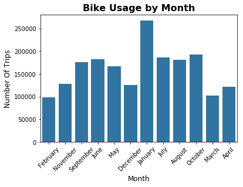

```python
figure = sb.countplot(data = df_new, x = 'start_time_month_name', color = sb.color_palette()[0]);
figure.set_title('Bike Usage by Month', fontsize = 16, fontweight = 'bold')
plt.xlabel('Month', fontsize = 12);
plt.ylabel('Number Of Trips', fontsize = 12);
plt.xticks(rotation = 45);
```

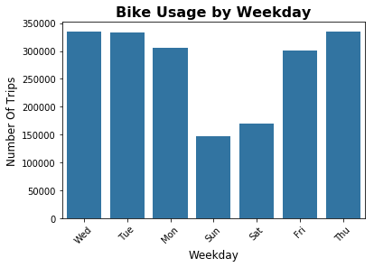

```python
figure = sb.countplot(data = df_new, x = 'start_time_weekday', color = sb.color_palette()[0]);
figure.set_title('Bike Usage by Weekday', fontsize = 16, fontweight = 'bold')
plt.xlabel('Weekday', fontsize = 12);
plt.ylabel('Number Of Trips', fontsize = 12);
plt.xticks(rotation = 45);
```

#### Insight Number 2 : Tuedays, wednesdays and hursdays are the most popular days for trips probably because of the commuters, while the saturadys and sundays are least popular because of holidays.

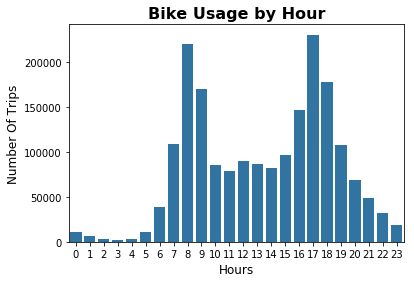

```python
figure = sb.countplot(data = df_new, x = 'start_time_hour', color = sb.color_palette()[0]);
figure.set_title('Bike Usage by Hour', fontsize = 16, fontweight = 'bold')
plt.xlabel('Hours', fontsize = 12);
plt.ylabel('Number Of Trips', fontsize = 12);
```

#### Insight Number 3 : The time brackets of 7am - 9am and 4pm - 6pm are the most popular hours which suggest that the bikes are primarily being used by commuters as these are the starting and ending time of most of the work places.

```python
df_new.duration_min.mean()
```

```
12.378941960393574
```

```python
df_new.duration_min.describe()
```

```
count    1.926960e+06
mean     1.237894e+01
std      3.247592e+01
min      1.000000e+00
25%      5.000000e+00
50%      9.000000e+00
75%      1.300000e+01
max      1.438000e+03
Name: duration_min, dtype: float64
```

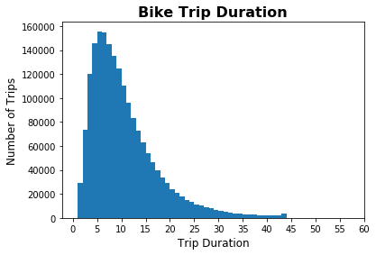

```python
bins = np.arange(0, 45, 1)
ticks = [0, 5, 10, 15, 20, 25, 30,  35, 40, 45, 50, 55, 60]
label = ['{}'.format(v) for v in ticks]

figure = sb.distplot(df_new['duration_min'], bins = bins, kde = False, hist_kws = {'alpha' : 1});
plt.title("Bike Trip Duration", fontsize = 16, fontweight = 'bold')
plt.xlabel('Trip Duration', fontsize = 12)
plt.ylabel('Number of Trips', fontsize = 12)
plt.xticks(ticks, label);
```

#### Insight Number 4 : The average trip is just under 12.5 minutes, with 75% of trips being under 13 minutes. Looking at the histogram, most rides fall in between the 3 - 11 minute range which suggests that riders are taking the bikes for short distances.

```python
df_new.member_age.describe()
```

```
count    1.926960e+06
mean     3.561008e+01
std      9.925085e+00
min      1.800000e+01
25%      2.800000e+01
50%      3.300000e+01
75%      4.100000e+01
max      7.000000e+01
Name: member_age, dtype: float64
```

```python
df_new.member_age.mean()
```

```
35.61008427782621
```

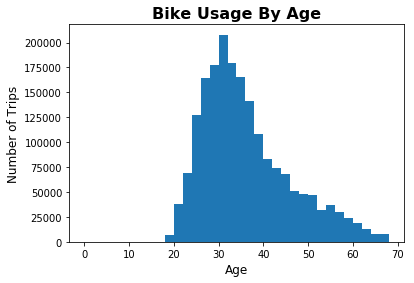

```python
bins = np.arange(0, 70, 2)
figure = sb.distplot(df_new['member_age'], bins = bins, kde = False, hist_kws = {'alpha' : 1});
plt.title("Bike Usage By Age", fontsize = 16, fontweight = 'bold');
plt.xlabel('Age', fontsize = 12);
plt.ylabel('Number of Trips', fontsize = 12);
```

#### Insight Number 5 : Accoring to the histogram, most member of the Ford GoBike are 25 - 40 years of age which suggest that primary members are either commuters or students. With maximum and minimum being 70 and 18 respectively. The average age of a bike rider is 35 years old.

```python
df_new.member_gender.value_counts()
```

```
Male      1416502
Female     480252
Other       30206
Name: member_gender, dtype: int64
```

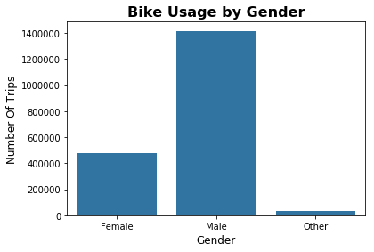

```python
figure = sb.countplot(data = df_new, x = 'member_gender', color = sb.color_palette()[0]);
figure.set_title('Bike Usage by Gender', fontsize = 16, fontweight = 'bold');
plt.xlabel('Gender', fontsize = 12);
plt.ylabel('Number Of Trips', fontsize = 12);
```

#### Insight Number 6 : The graph clearly indicates that majority of riders are males, accounting to approx 70% of total users.

### Discuss the distribution(s) of your variable(s) of interest. Were there any unusual points? Did you need to perform any transformations?

> The distribution of my variables of interest are pretty much what i expected becuase of te wrangling process this dataset went through earlier.

### Of the features you investigated, were there any unusual distributions? Did you perform any operations on the data to tidy, adjust, or change the form of the data? If so, why did you do this?

> There was one unusual point though which was january being the most popular month for bike riders, the reason this is unusual is because january is one of most coldest months.

## Bivariate Exploration

> In this section, I investigate relationships between pairs of variables in the data.

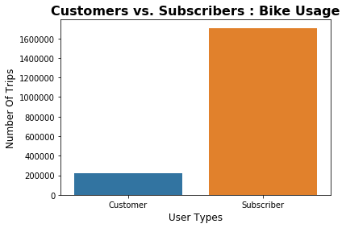

```python
customer = df_new.query('user_type == "Customer"')['bike_id'].count();
subscriber = df_new.query('user_type == "Subscriber"')['bike_id'].count();
figure = sb.countplot(data = df_new, x = 'user_type');
figure.set_title('Customers vs. Subscribers : Bike Usage', fontsize = 16, fontweight = 'bold');
plt.xlabel('User Types', fontsize = 12);
plt.ylabel('Number Of Trips', fontsize = 12);
```

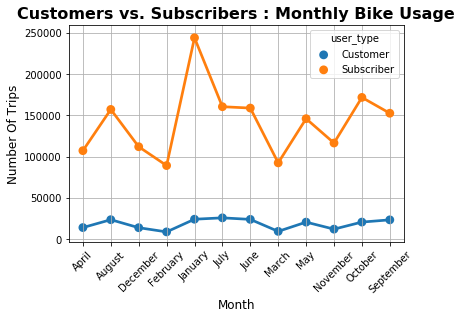

```python
df_new_user_month = df_new.groupby(['start_time_month_name', 'user_type']).size().reset_index();
figure = sb.pointplot(data = df_new_user_month, x = 'start_time_month_name', y = 0, hue = 'user_type');
figure.set_title('Customers vs. Subscribers : Monthly Bike Usage', fontsize = 16, fontweight = 'bold');
plt.xlabel('Month', fontsize = 12);
plt.ylabel('Number Of Trips', fontsize = 12);
plt.xticks(rotation = 45);
plt.grid();
```

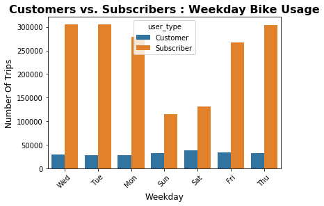

```python
figure = sb.countplot(data = df_new, x = 'start_time_weekday', hue = 'user_type');
figure.set_title('Customers vs. Subscribers : Weekday Bike Usage', fontsize = 16, fontweight = 'bold');
plt.xlabel('Weekday', fontsize = 12);
plt.ylabel('Number Of Trips', fontsize = 12);
plt.xticks(rotation = 45);
```

#### Insight Number 9 : This countplot indicates that the number of random customers through out the weekdays are almost the same with saturdays being the most popular as opposed to the number of subscribers being high during the weekdays and less during the weekends.

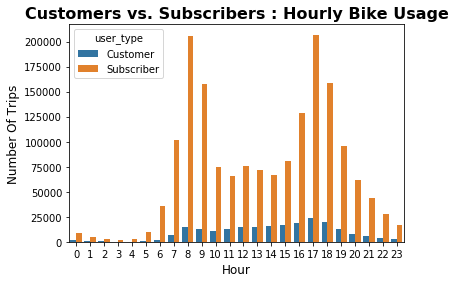

```python
figure = sb.countplot(data = df_new, x = 'start_time_hour', hue = 'user_type');
figure.set_title('Customers vs. Subscribers : Hourly Bike Usage', fontsize = 16, fontweight = 'bold');
plt.xlabel('Hour', fontsize = 12);
plt.ylabel('Number Of Trips', fontsize = 12);
```

#### Insight Number 10 : The number of random customers remains somwhat the same from 8am-9pms, while the number of subscribers are at peak during the time brackets of 8am - 10am and 5pm - 7pm.

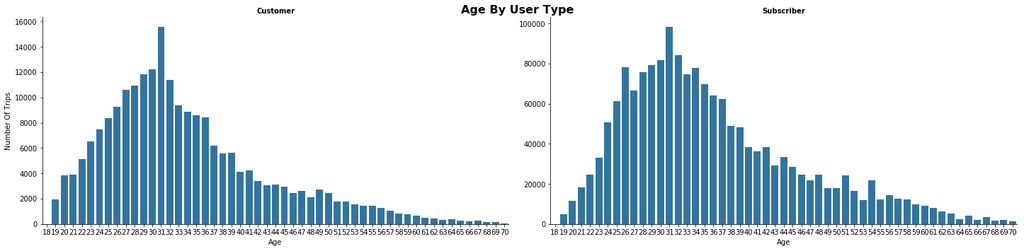

```python
figure = sb.catplot(data = df_new, x = 'member_age', col = 'user_type', kind = 'count', sharey = False, color = sb.color_palette()[0], height = 5, aspect = 2);
figure.set_titles('{col_name}', fontsize = 16, y = 1.05, fontweight = 'bold');
figure.fig.suptitle('Age By User Type', fontsize = 16, fontweight = 'bold');
figure.set_axis_labels('Age', 'Number Of Trips');
```

#### Insight Number 11 : Both user type graphs show the high number of 31 year olds. Subscribers have a wider range of ages while customers tends to have mostly younger users.

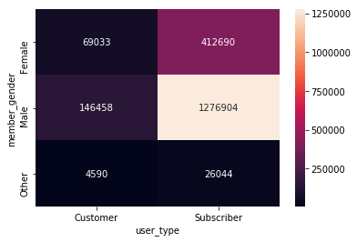

```python
figure = df.groupby(['user_type', 'member_gender']).size();
figure = figure.reset_index(name = 'count');
figure = figure.pivot(index = 'member_gender', columns = 'user_type', values = 'count');
sb.heatmap(figure, annot = True, fmt = 'd');
```

#### Insight Number 12 : The heat map detects that most number of trips are performed by subscribers who are males followed by female subscribers, while the customer group which are neither males nor females have the lowest number of trips.

### Talk about some of the relationships you observed in this part of the investigation. How did the feature(s) of interest vary with other features in the dataset?

> This section briefly explains the relationship of user types with other variables. It shows us how the data is distributed among subscribers and customers with regard to months, weekdays, hours, age and gender.

### Did you observe any interesting relationships between the other features (not the main feature(s) of interest)?

> Yes, the insteresting relations observed between other features are the difference in number of trips between both the user types. It was also noted that customer trips are usually longer than the subscriber ones.

## Multivariate Exploration

> In this section, I will create plots of three or more variables to investigate the data even further.

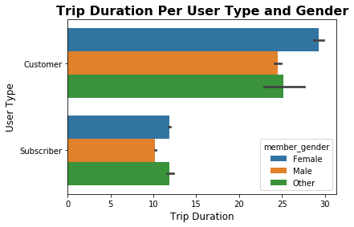

```python
figure = sb.barplot(data = df_new, x = 'duration_min', y = 'user_type', hue = 'member_gender');
figure.set_title('Trip Duration Per User Type and Gender', fontsize = 16, fontweight = 'bold');
plt.xlabel('Trip Duration', fontsize = 12);
plt.ylabel('User Type', fontsize = 12);
```

#### Insight Number 13 : This multivariate bar plot shows that the female customers have been on the longest trips as compared to the duration of trips by male customes. This graph proves that the customer trips are longer than the subscriber trips suggesting that subsribers are mostly commuters while random customers are tourists.

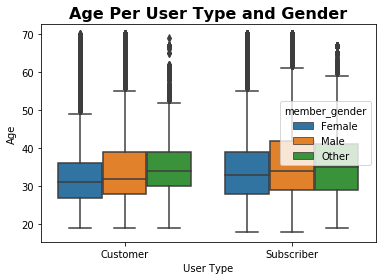

```python
figure = sb.boxplot(data = df_new, x = "user_type", y = 'member_age', hue = "member_gender");
figure.set_title('Age Per User Type and Gender', fontsize = 16, fontweight = 'bold');
figure.set_xlabel('User Type');
figure.set_ylabel('Age');
```

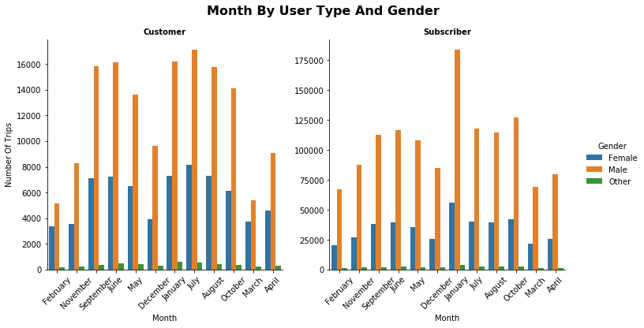

```python
figure = sb.catplot(data = df_new, x = 'start_time_month_name', col = "user_type", hue = 'member_gender', kind = 'count', sharey = False);
figure.set_titles('{col_name}', fontsize = 16, fontweight = 'bold');
figure.fig.suptitle('Month By User Type And Gender', y = 1.05, fontsize = 16, fontweight = 'bold');
figure.set_axis_labels('Month', 'Number Of Trips');
figure._legend.set_title('Gender');
figure.set_xticklabels(rotation = 45);
```

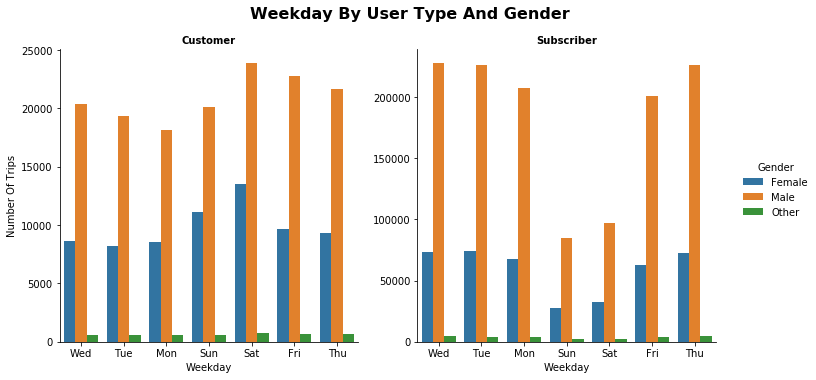

```python
figure = sb.catplot(data = df_new, x = 'start_time_weekday', col = "user_type", hue = 'member_gender', kind = 'count', sharey = False);
figure.set_titles('{col_name}', fontsize = 16, fontweight = 'bold');
figure.fig.suptitle('Weekday By User Type And Gender', y = 1.05, fontsize = 16, fontweight = 'bold');
figure.set_axis_labels('Weekday', 'Number Of Trips');
figure._legend.set_title('Gender');
```

#### Insight Number 16 : Weekends is the most populated day for the both the males and females customers because these are holiday, while a total opposite trend can be seen in the subscribers graph where the weekends are the least favourite for both the males and the females. This suggests that random customer are mainly customers while the subscribers are mostly daily commuters.

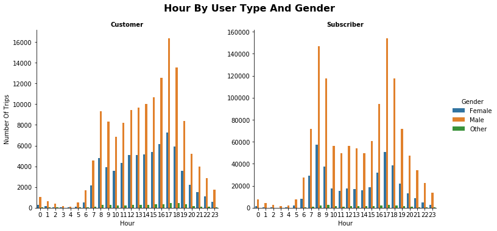

```python
figure = sb.catplot(data = df_new, x = 'start_time_hour', col = "user_type", hue = 'member_gender', kind = 'count', sharey = False);
figure.set_titles('{col_name}', fontsize = 16, fontweight = 'bold');
figure.fig.suptitle('Hour By User Type And Gender', y = 1.05, fontsize = 16, fontweight = 'bold');
figure.set_axis_labels('Hour', 'Number Of Trips');
figure._legend.set_title('Gender');
```

#### Insight Number 17 : During the day, both males and females use the system the same way: customers use bikes mainly between 8 am - 7 pm; subscribers on the other side use the system at around 8-9am and 5-6pm when they go and come back from work.

### Talk about some of the relationships you observed in this part of the investigation. Were there features that strengthened each other in terms of looking at your feature(s) of interest?

> This section further amplified the results of previous univariate and multivariate sections, as now in this section we are deduced the relationships between more than 2 variables. Plotting the number bike trips throughout the day and number of bike trips within the weekdays separately gave the impression that the demand for bikes is quite high throughout the day with a peak around 5pm which. The trend within weekdays for customers follows the one for subscribers who rent bikes mainly around commute hours. For customers, most of the trips happen on weekends.

## Conclusion :

```python
df_new.to_csv("clean_file.csv")
```